# Predikcija odustajanja učenika

```r
options(repos = c(CRAN = "https://cran.r-project.org"))

library(dplyr)
df <- read.csv("data.csv", sep = ";")

# Prilagodba naziva varijabli
names(df) <- make.names(names(df))

# Pogled prvih par redova
head(df)
```

|  | Marital.status | Application.mode | Application.order | Course | Daytime.evening.attendance. | Previous.qualification | Previous.qualification..grade. | Nacionality | Mother.s.qualification | Father.s.qualification | Mother.s.occupation | Father.s.occupation | Admission.grade | Displaced | Educational.special.needs | Debtor | Tuition.fees.up.to.date | Gender | Scholarship.holder | Age.at.enrollment | International | Curricular.units.1st.sem..credited. | Curricular.units.1st.sem..enrolled. | Curricular.units.1st.sem..evaluations. | Curricular.units.1st.sem..approved. | Curricular.units.1st.sem..grade. | Curricular.units.1st.sem..without.evaluations. | Curricular.units.2nd.sem..credited. | Curricular.units.2nd.sem..enrolled. | … |
| --- | --- | --- | --- | --- | --- | --- | --- | --- | --- | --- | --- | --- | --- | --- | --- | --- | --- | --- | --- | --- | --- | --- | --- | --- | --- | --- | --- | --- | --- | --- |
| 1 | 1 | 17 | 5 | 171 | 1 | 1 | 122.0 | 1 | 19 | 12 | 5 | 9 | 127.3 | 1 | 0 | 0 | 1 | 1 | 0 | 20 | 0 | 0 | 0 | 0 | 0 | 0.00000 | 0 | 0 | 0 | … |
| 2 | 1 | 15 | 1 | 9254 | 1 | 1 | 160.0 | 1 | 1 | 3 | 3 | 3 | 142.5 | 1 | 0 | 0 | 0 | 1 | 0 | 19 | 0 | 0 | 6 | 6 | 6 | 14.00000 | 0 | 0 | 6 | … |
| 3 | 1 | 1 | 5 | 9070 | 1 | 1 | 122.0 | 1 | 37 | 37 | 9 | 9 | 124.8 | 1 | 0 | 0 | 0 | 1 | 0 | 19 | 0 | 0 | 6 | 0 | 0 | 0.00000 | 0 | 0 | 6 | … |
| 4 | 1 | 17 | 2 | 9773 | 1 | 1 | 122.0 | 1 | 38 | 37 | 5 | 3 | 119.6 | 1 | 0 | 0 | 1 | 0 | 0 | 20 | 0 | 0 | 6 | 8 | 6 | 13.42857 | 0 | 0 | 6 | … |
| 5 | 2 | 39 | 1 | 8014 | 0 | 1 | 100.0 | 1 | 37 | 38 | 9 | 9 | 141.5 | 0 | 0 | 0 | 1 | 0 | 0 | 45 | 0 | 0 | 6 | 9 | 5 | 12.33333 | 0 | 0 | 6 | … |
| 6 | 2 | 39 | 1 | 9991 | 0 | 19 | 133.1 | 1 | 37 | 37 | 9 | 7 | 114.8 | 0 | 0 | 1 | 1 | 1 | 0 | 50 | 0 | 0 | 5 | 10 | 5 | 11.85714 | 0 | 0 | 5 | … |

```r
# Struktura podataka
str(df)
```

```
## 'data.frame':    4424 obs. of  37 variables:
##  $ Marital.status                                : int  1 1 1 1 2 2 1 1 1 1 ...
##  $ Application.mode                              : int  17 15 1 17 39 39 1 18 1 1 ...
##  $ Application.order                             : int  5 1 5 2 1 1 1 4 3 1 ...
##  $ Course                                        : int  171 9254 9070 9773 8014 9991 9500 9254 9238 9238 ...
##  $ Daytime.evening.attendance.                   : int  1 1 1 1 0 0 1 1 1 1 ...
##  $ Previous.qualification                        : int  1 1 1 1 1 19 1 1 1 1 ...
##  $ Previous.qualification..grade.                : num  122 160 122 122 100 ...
##  $ Nacionality                                   : int  1 1 1 1 1 1 1 1 62 1 ...
##  $ Mother.s.qualification                        : int  19 1 37 38 37 37 19 37 1 1 ...
##  $ Father.s.qualification                        : int  12 3 37 37 38 37 38 37 1 19 ...
##  $ Mother.s.occupation                           : int  5 3 9 5 9 9 7 9 9 4 ...
##  $ Father.s.occupation                           : int  9 3 9 3 9 7 10 9 9 7 ...
##  $ Admission.grade                               : num  127 142 125 120 142 ...
##  $ Displaced                                     : int  1 1 1 1 0 0 1 1 0 1 ...
```

[output cut: 23 more lines]

```r
# Sažetak skupa podataka:
# Kratak sažetak svih varijabli
summary(df)
```

```
##  Marital.status  Application.mode Application.order     Course
##  Min.   :1.000   Min.   : 1.00    Min.   :0.000     Min.   :  33
##  1st Qu.:1.000   1st Qu.: 1.00    1st Qu.:1.000     1st Qu.:9085
##  Median :1.000   Median :17.00    Median :1.000     Median :9238
##  Mean   :1.179   Mean   :18.67    Mean   :1.728     Mean   :8857
##  3rd Qu.:1.000   3rd Qu.:39.00    3rd Qu.:2.000     3rd Qu.:9556
##  Max.   :6.000   Max.   :57.00    Max.   :9.000     Max.   :9991
##  Daytime.evening.attendance. Previous.qualification
##  Min.   :0.0000              Min.   : 1.000
##  1st Qu.:1.0000              1st Qu.: 1.000
##  Median :1.0000              Median : 1.000
##  Mean   :0.8908              Mean   : 4.578
##  3rd Qu.:1.0000              3rd Qu.: 1.000
##  Max.   :1.0000              Max.   :43.000
##  Previous.qualification..grade.  Nacionality      Mother.s.qualification
##  Min.   : 95.0                  Min.   :  1.000   Min.   : 1.00
##  1st Qu.:125.0                  1st Qu.:  1.000   1st Qu.: 2.00
##  Median :133.1                  Median :  1.000   Median :19.00
##  Mean   :132.6                  Mean   :  1.873   Mean   :19.56
##  3rd Qu.:140.0                  3rd Qu.:  1.000   3rd Qu.:37.00
##  Max.   :190.0                  Max.   :109.000   Max.   :44.00
##  Father.s.qualification Mother.s.occupation Father.s.occupation Admission.grade
##  Min.   : 1.00          Min.   :  0.00      Min.   :  0.00      Min.   : 95.0
##  1st Qu.: 3.00          1st Qu.:  4.00      1st Qu.:  4.00      1st Qu.:117.9
##  Median :19.00          Median :  5.00      Median :  7.00      Median :126.1
##  Mean   :22.28          Mean   : 10.96      Mean   : 11.03      Mean   :127.0
##  3rd Qu.:37.00          3rd Qu.:  9.00      3rd Qu.:  9.00      3rd Qu.:134.8
##  Max.   :44.00          Max.   :194.00      Max.   :195.00      Max.   :190.0
##    Displaced      Educational.special.needs     Debtor
##  Min.   :0.0000   Min.   :0.00000           Min.   :0.0000
##  1st Qu.:0.0000   1st Qu.:0.00000           1st Qu.:0.0000
##  Median :1.0000   Median :0.00000           Median :0.0000
##  Mean   :0.5484   Mean   :0.01153           Mean   :0.1137
##  3rd Qu.:1.0000   3rd Qu.:0.00000           3rd Qu.:0.0000
##  Max.   :1.0000   Max.   :1.00000           Max.   :1.0000
##  Tuition.fees.up.to.date     Gender       Scholarship.holder Age.at.enrollment
##  Min.   :0.0000          Min.   :0.0000   Min.   :0.0000     Min.   :17.00
##  1st Qu.:1.0000          1st Qu.:0.0000   1st Qu.:0.0000     1st Qu.:19.00
##  Median :1.0000          Median :0.0000   Median :0.0000     Median :20.00
##  Mean   :0.8807          Mean   :0.3517   Mean   :0.2484     Mean   :23.27
```

[output cut: 50 more lines]

```
##  Max.   :18.57
##  Curricular.units.2nd.sem..without.evaluations. Unemployment.rate
##  Min.   : 0.0000                                Min.   : 7.60
##  1st Qu.: 0.0000                                1st Qu.: 9.40
##  Median : 0.0000                                Median :11.10
##  Mean   : 0.1503                                Mean   :11.57
##  3rd Qu.: 0.0000                                3rd Qu.:13.90
##  Max.   :12.0000                                Max.   :16.20
##  Inflation.rate        GDP               Target
##  Min.   :-0.800   Min.   :-4.060000   Length:4424
##  1st Qu.: 0.300   1st Qu.:-1.700000   Class :character
##  Median : 1.400   Median : 0.320000   Mode  :character
##  Mean   : 1.228   Mean   : 0.001969
##  3rd Qu.: 2.600   3rd Qu.: 1.790000
##  Max.   : 3.700   Max.   : 3.510000
```

```r
# Detaljan opis po tipu (kvantitativne, kvalitativne)
library(skimr)
skim(df)
```

Data summary

| Name | df |
| --- | --- |
| Number of rows | 4424 |
| Number of columns | 37 |
| _______________________ |  |
| Column type frequency: |  |
| character | 1 |
| numeric | 36 |
| ________________________ |  |
| Group variables | None |

**Variable type: character**

| skim_variable | n_missing | complete_rate | min | max | empty | n_unique | whitespace |
| --- | --- | --- | --- | --- | --- | --- | --- |
| Target | 0 | 1 | 7 | 8 | 0 | 3 | 0 |

**Variable type: numeric**

| skim_variable | n_missing | complete_rate | mean | sd | p0 | p25 | p50 | p75 | p100 | hist |
| --- | --- | --- | --- | --- | --- | --- | --- | --- | --- | --- |
| Marital.status | 0 | 1 | 1.18 | 0.61 | 1.00 | 1.00 | 1.00 | 1.00 | 6.00 | ▇▁▁▁▁ |
| Application.mode | 0 | 1 | 18.67 | 17.48 | 1.00 | 1.00 | 17.00 | 39.00 | 57.00 | ▇▅▁▆▁ |
| Application.order | 0 | 1 | 1.73 | 1.31 | 0.00 | 1.00 | 1.00 | 2.00 | 9.00 | ▇▂▁▁▁ |
| Course | 0 | 1 | 8856.64 | 2063.57 | 33.00 | 9085.00 | 9238.00 | 9556.00 | 9991.00 | ▁▁▁▁▇ |
| Daytime.evening.attendance. | 0 | 1 | 0.89 | 0.31 | 0.00 | 1.00 | 1.00 | 1.00 | 1.00 | ▁▁▁▁▇ |
| Previous.qualification | 0 | 1 | 4.58 | 10.22 | 1.00 | 1.00 | 1.00 | 1.00 | 43.00 | ▇▁▁▁▁ |
| Previous.qualification..grade. | 0 | 1 | 132.61 | 13.19 | 95.00 | 125.00 | 133.10 | 140.00 | 190.00 | ▁▇▇▁▁ |
| Nacionality | 0 | 1 | 1.87 | 6.91 | 1.00 | 1.00 | 1.00 | 1.00 | 109.00 | ▇▁▁▁▁ |
| Mother.s.qualification | 0 | 1 | 19.56 | 15.60 | 1.00 | 2.00 | 19.00 | 37.00 | 44.00 | ▇▁▅▁▇ |
| Father.s.qualification | 0 | 1 | 22.28 | 15.34 | 1.00 | 3.00 | 19.00 | 37.00 | 44.00 | ▆▁▅▁▇ |
| Mother.s.occupation | 0 | 1 | 10.96 | 26.42 | 0.00 | 4.00 | 5.00 | 9.00 | 194.00 | ▇▁▁▁▁ |
| Father.s.occupation | 0 | 1 | 11.03 | 25.26 | 0.00 | 4.00 | 7.00 | 9.00 | 195.00 | ▇▁▁▁▁ |
| Admission.grade | 0 | 1 | 126.98 | 14.48 | 95.00 | 117.90 | 126.10 | 134.80 | 190.00 | ▂▇▃▁▁ |
| Displaced | 0 | 1 | 0.55 | 0.50 | 0.00 | 0.00 | 1.00 | 1.00 | 1.00 | ▆▁▁▁▇ |
| Educational.special.needs | 0 | 1 | 0.01 | 0.11 | 0.00 | 0.00 | 0.00 | 0.00 | 1.00 | ▇▁▁▁▁ |
| Debtor | 0 | 1 | 0.11 | 0.32 | 0.00 | 0.00 | 0.00 | 0.00 | 1.00 | ▇▁▁▁▁ |
| Tuition.fees.up.to.date | 0 | 1 | 0.88 | 0.32 | 0.00 | 1.00 | 1.00 | 1.00 | 1.00 | ▁▁▁▁▇ |
| Gender | 0 | 1 | 0.35 | 0.48 | 0.00 | 0.00 | 0.00 | 1.00 | 1.00 | ▇▁▁▁▅ |
| Scholarship.holder | 0 | 1 | 0.25 | 0.43 | 0.00 | 0.00 | 0.00 | 0.00 | 1.00 | ▇▁▁▁▂ |
| Age.at.enrollment | 0 | 1 | 23.27 | 7.59 | 17.00 | 19.00 | 20.00 | 25.00 | 70.00 | ▇▁▁▁▁ |
| International | 0 | 1 | 0.02 | 0.16 | 0.00 | 0.00 | 0.00 | 0.00 | 1.00 | ▇▁▁▁▁ |
| Curricular.units.1st.sem..credited. | 0 | 1 | 0.71 | 2.36 | 0.00 | 0.00 | 0.00 | 0.00 | 20.00 | ▇▁▁▁▁ |
| Curricular.units.1st.sem..enrolled. | 0 | 1 | 6.27 | 2.48 | 0.00 | 5.00 | 6.00 | 7.00 | 26.00 | ▃▇▁▁▁ |
| Curricular.units.1st.sem..evaluations. | 0 | 1 | 8.30 | 4.18 | 0.00 | 6.00 | 8.00 | 10.00 | 45.00 | ▇▃▁▁▁ |
| Curricular.units.1st.sem..approved. | 0 | 1 | 4.71 | 3.09 | 0.00 | 3.00 | 5.00 | 6.00 | 26.00 | ▇▆▁▁▁ |
| Curricular.units.1st.sem..grade. | 0 | 1 | 10.64 | 4.84 | 0.00 | 11.00 | 12.29 | 13.40 | 18.88 | ▂▁▂▇▁ |
| Curricular.units.1st.sem..without.evaluations. | 0 | 1 | 0.14 | 0.69 | 0.00 | 0.00 | 0.00 | 0.00 | 12.00 | ▇▁▁▁▁ |
| Curricular.units.2nd.sem..credited. | 0 | 1 | 0.54 | 1.92 | 0.00 | 0.00 | 0.00 | 0.00 | 19.00 | ▇▁▁▁▁ |
| Curricular.units.2nd.sem..enrolled. | 0 | 1 | 6.23 | 2.20 | 0.00 | 5.00 | 6.00 | 7.00 | 23.00 | ▁▇▁▁▁ |
| Curricular.units.2nd.sem..evaluations. | 0 | 1 | 8.06 | 3.95 | 0.00 | 6.00 | 8.00 | 10.00 | 33.00 | ▃▇▁▁▁ |
| Curricular.units.2nd.sem..approved. | 0 | 1 | 4.44 | 3.01 | 0.00 | 2.00 | 5.00 | 6.00 | 20.00 | ▆▇▁▁▁ |
| Curricular.units.2nd.sem..grade. | 0 | 1 | 10.23 | 5.21 | 0.00 | 10.75 | 12.20 | 13.33 | 18.57 | ▂▁▁▇▁ |
| Curricular.units.2nd.sem..without.evaluations. | 0 | 1 | 0.15 | 0.75 | 0.00 | 0.00 | 0.00 | 0.00 | 12.00 | ▇▁▁▁▁ |
| Unemployment.rate | 0 | 1 | 11.57 | 2.66 | 7.60 | 9.40 | 11.10 | 13.90 | 16.20 | ▆▆▇▂▅ |
| Inflation.rate | 0 | 1 | 1.23 | 1.38 | -0.80 | 0.30 | 1.40 | 2.60 | 3.70 | ▆▇▆▆▃ |
| GDP | 0 | 1 | 0.00 | 2.27 | -4.06 | -1.70 | 0.32 | 1.79 | 3.51 | ▆▂▆▇▅ |

### Definiranje podskupa od 1500 opservacija sa stratificiranim omjerima po varijabli Target

```r
# Raspodjela klasa u originalnom skupu
table(df$Target)
```

```
##
##  Dropout Enrolled Graduate
##     1421      794     2209
```

```r
prop.table(table(df$Target))  # relativne frekvencije
```

```
##
##   Dropout  Enrolled  Graduate
## 0.3212025 0.1794756 0.4993219
```

```r
# Broj opservacija u podskupu
N <- 1500

# Stratificirano uzorkovanje
set.seed(123)  # reproducibilnost

library(dplyr)

df_sample <- df %>%
  group_by(Target) %>%
  sample_frac(size = N / nrow(df)) %>%
  ungroup()

# Provjera rezultata
table(df_sample$Target)
```

```
##
##  Dropout Enrolled Graduate
##      482      269      749
```

```r
prop.table(table(df_sample$Target))
```

```
##
##   Dropout  Enrolled  Graduate
## 0.3213333 0.1793333 0.4993333
```

```r
nrow(df_sample) # cca. 1500
```

```
## [1] 1500
```

| Klasifikacija | Originalno | Uzorak | Omjer u originalu | Omjer u uzorku |
| --- | --- | --- | --- | --- |
| **Dropout** | 1421 | 482 | 32.12% | 32.13% |
| **Enrolled** | 794 | 269 | 17.95% | 17.93% |
| **Graduate** | 2209 | 749 | 49.93% | 49.93% |
| **Ukupno** | 4424 | 1500 | 100% | 100% |

Kako bismo smanjili dimenzionalnost skupa podataka i ubrzali analizu, konstruiran je stratificirani uzorak od 1500 opservacija. Pri tome je zadržana izvorna raspodjela ciljne varijable Target koja sadrži tri klase: “Dropout”, “Enrolled” i “Graduate”. Tako konstruirani uzorak reprezentativan je s obzirom na ishode studenata te je prikazan gornjom tablicom.

## Deskriptivna statistika

Iako su mnoge varijable bile zapisane kao cijeli brojevi (int), temeljem opisa podataka one predstavljaju kategorizirane informacije (npr. bračni status, spol, razina obrazovanja roditelja) te su stoga konvertirane u factor tip u R-u. Time se omogućuje ispravna analiza, vizualizacija i interpretacija. Varijable koje mjere količine (npr. ocjene, broj upisanih predmeta) zadržane su kao kvantitativne varijable (numeric).

## Kvantitativne varijable

```r
kvantitativne <- c(
  "Previous.qualification..grade.",
  "Admission.grade",
  "Age.at.enrollment",
  "Curricular.units.1st.sem..grade.",
  "Curricular.units.2nd.sem..grade.",
  "Unemployment.rate",
  "Inflation.rate",
  "GDP",
  "Curricular.units.1st.sem..credited.",
  "Curricular.units.1st.sem..enrolled.",
  "Curricular.units.1st.sem..evaluations.",
  "Curricular.units.1st.sem..approved.",
  "Curricular.units.1st.sem..without.evaluations.",
  "Curricular.units.2nd.sem..credited.",
  "Curricular.units.2nd.sem..enrolled.",
  "Curricular.units.2nd.sem..evaluations.",
  "Curricular.units.2nd.sem..approved.",
  "Curricular.units.2nd.sem..without.evaluations."
)
```

```r
# Desktiptivna statistika kvant. varijabli:
df_kv <- df_sample[, kvantitativne]
library(dplyr)

deskriptiva_kv <- df_kv %>%
  summarise_all(list(
    Srednja = mean,
    Medijan = median,
    SD = sd,
    Q1 = ~quantile(., 0.25),
    Q3 = ~quantile(., 0.75),
    Min = min,
    Max = max
  ), na.rm = TRUE)

# Transponiranje za preglednost
deskriptiva_kv_t <- t(deskriptiva_kv)

# Prikaz tablice
knitr::kable(deskriptiva_kv_t, digits = 2,
             col.names = c("Srednja", "Medijan", "SD", "Q1", "Q3", "Min", "Max"),
             caption = "Deskriptivna statistika kvantitativnih varijabli")
```

Deskriptivna statistika kvantitativnih varijabli

[output not shown]

[output cut: 96 more lines]

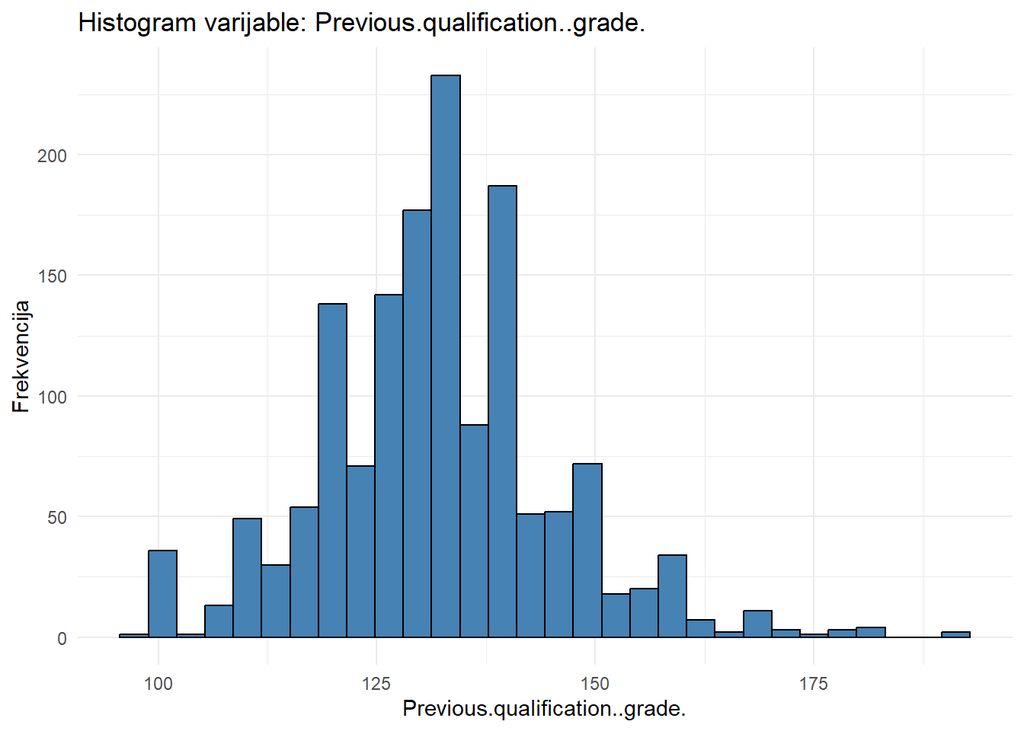

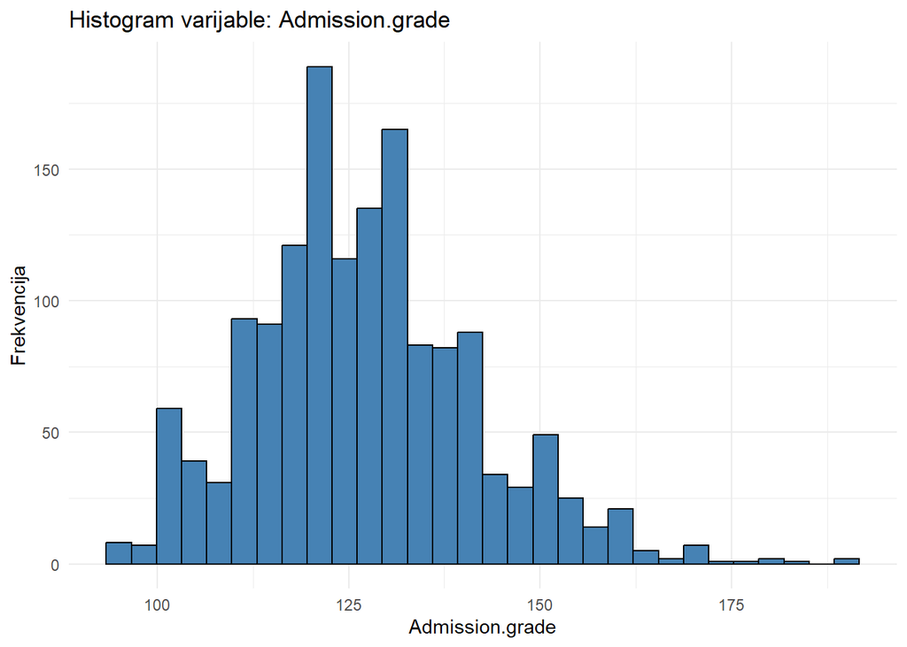

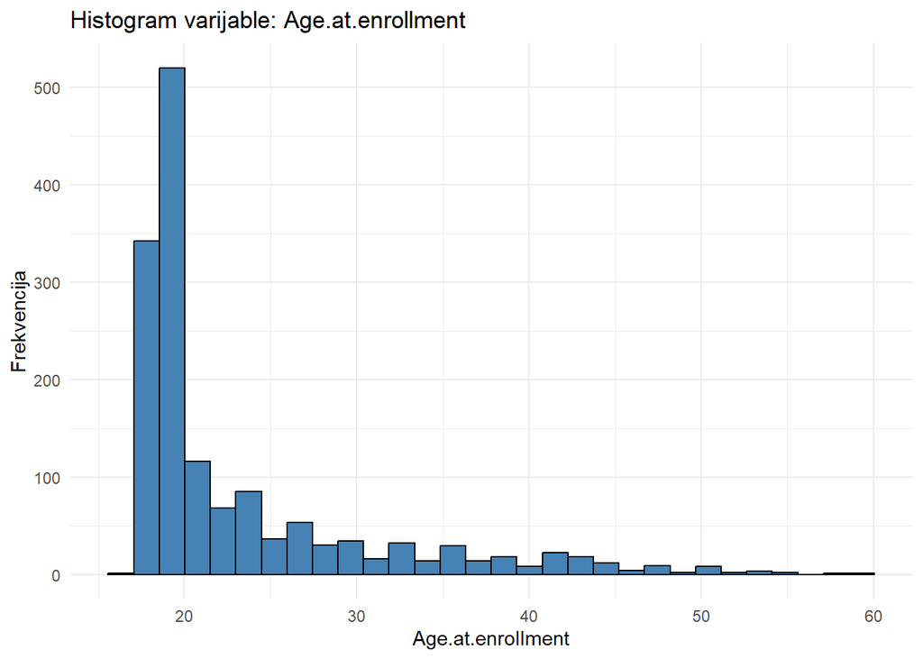

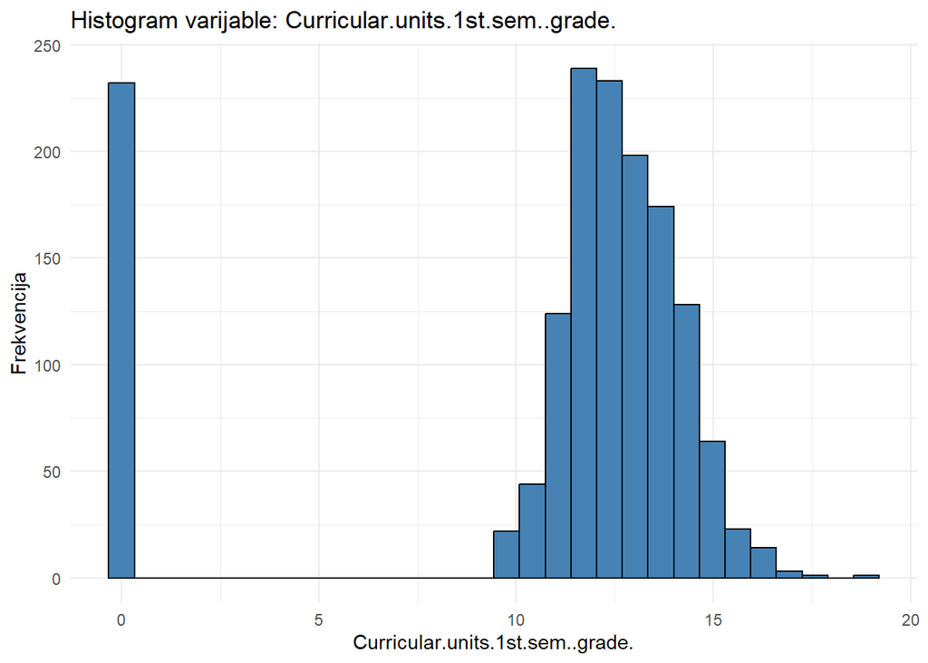

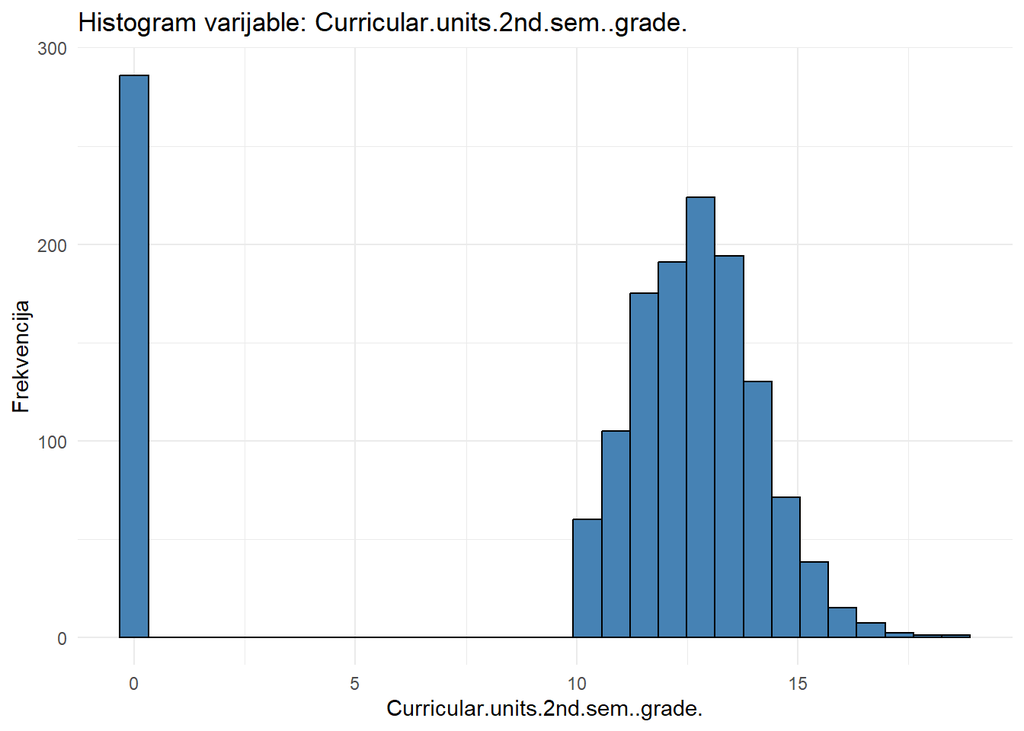

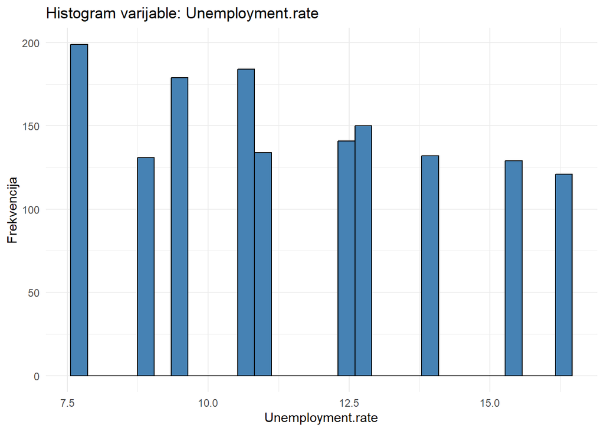

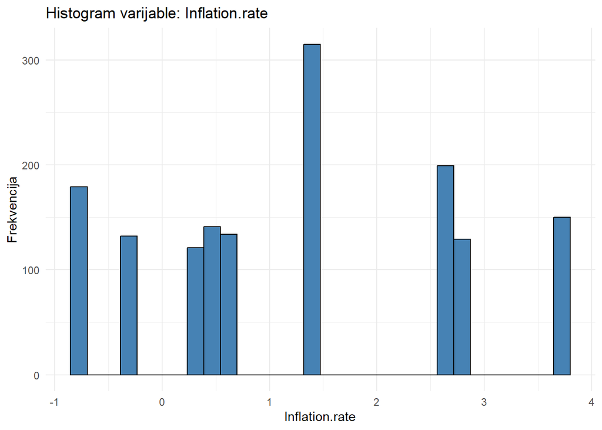

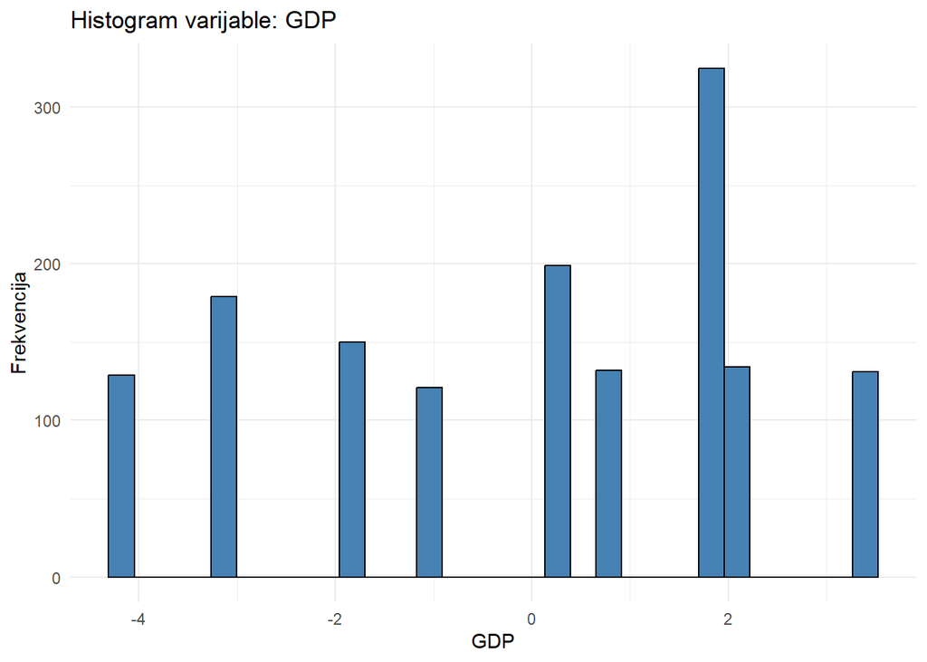

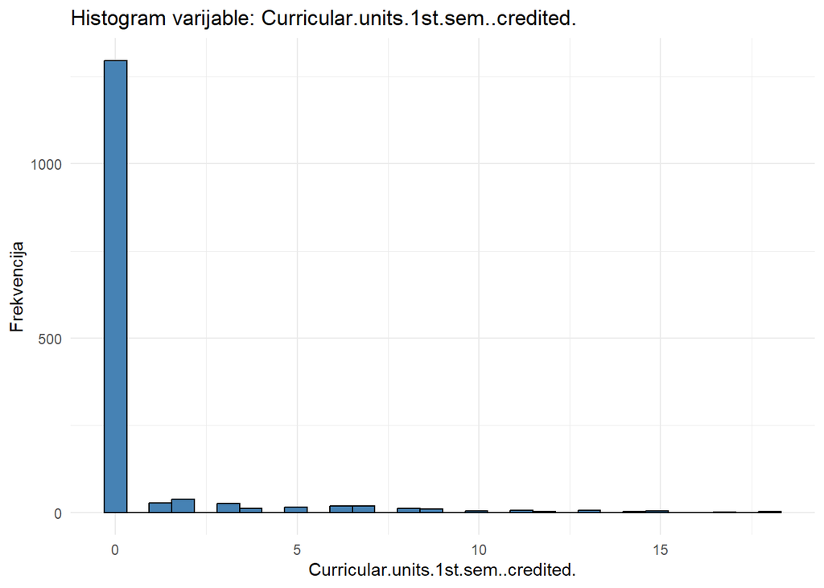

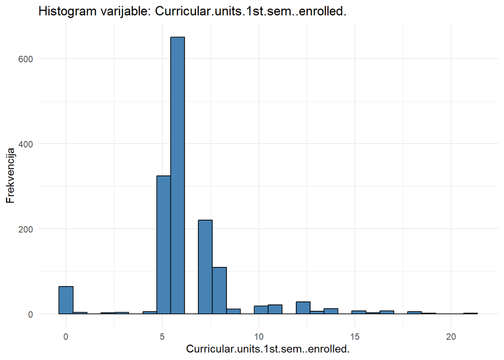

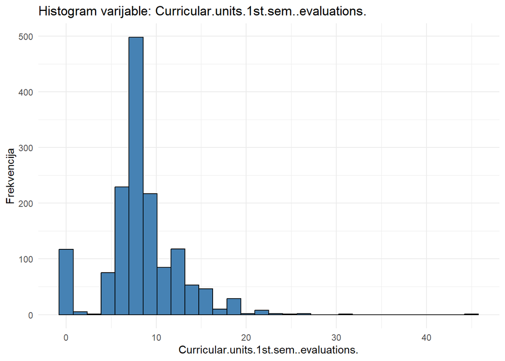

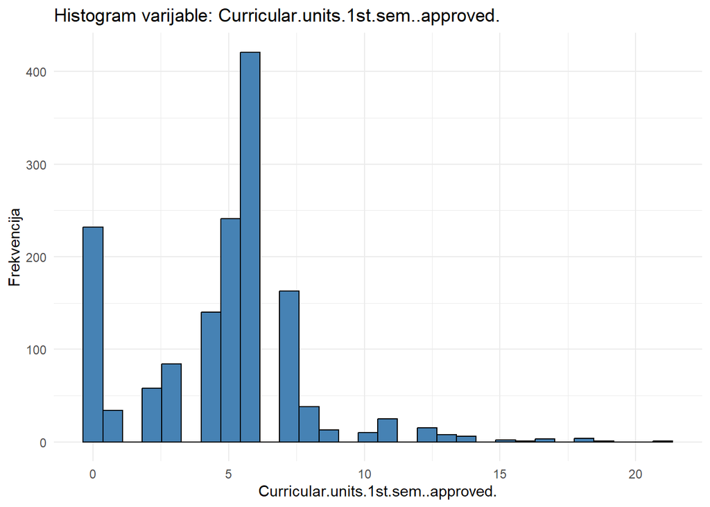

[6 more figures not shown]

```r
# Grafički prikaz histograma:
library(ggplot2)

for (var in kvantitativne) {
  print(
    ggplot(df_sample, aes_string(x = var)) +
      geom_histogram(fill = "steelblue", color = "black", bins = 30) +
      labs(title = paste("Histogram varijable:", var), x = var, y = "Frekvencija") +
      theme_minimal()
  )
}
```

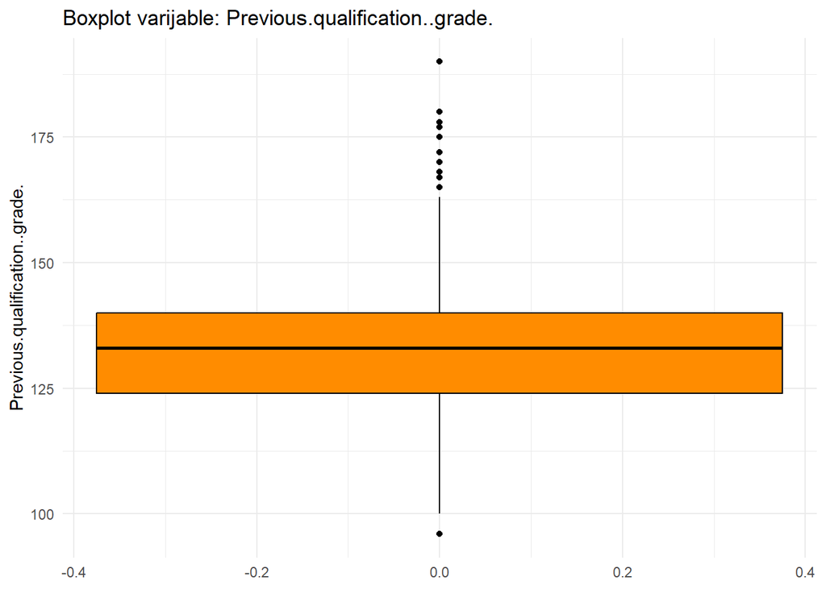

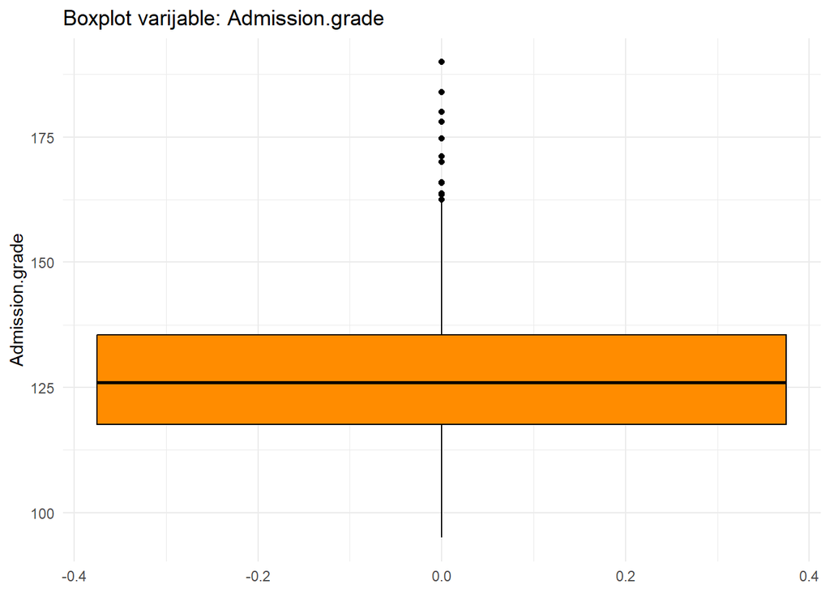

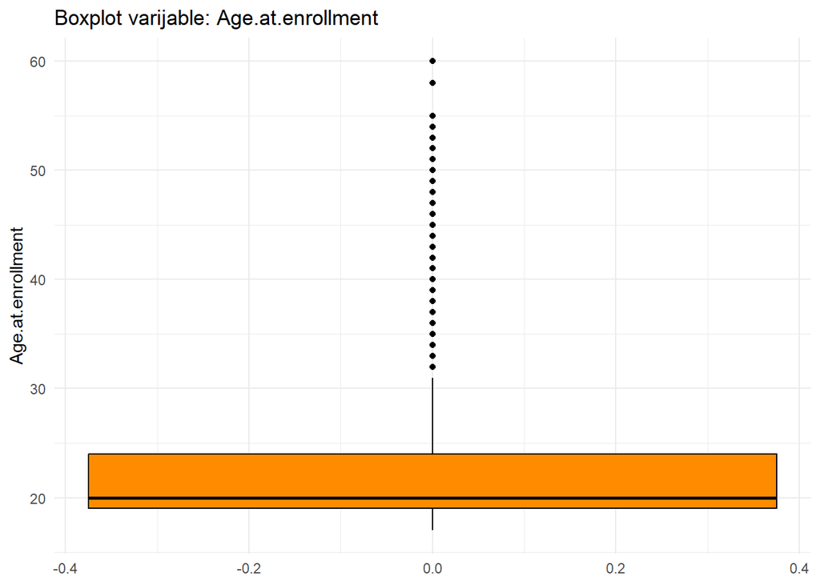

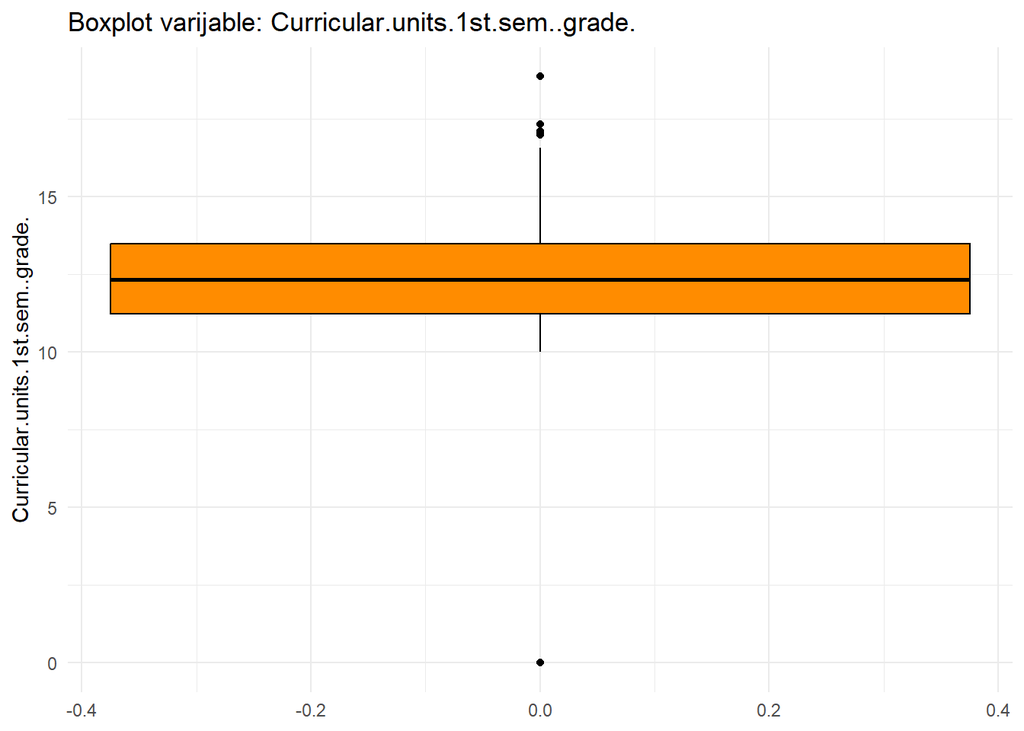

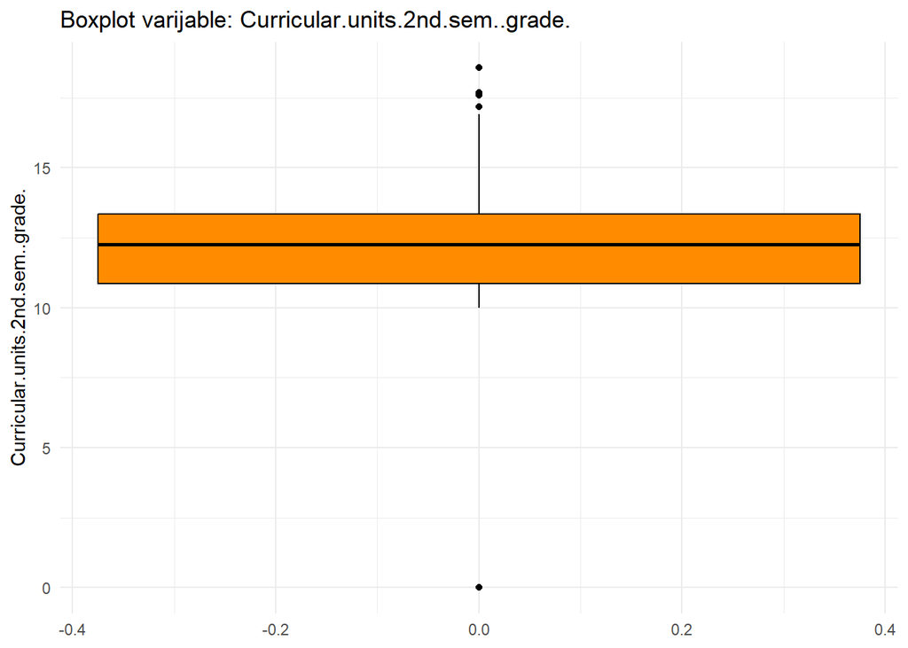

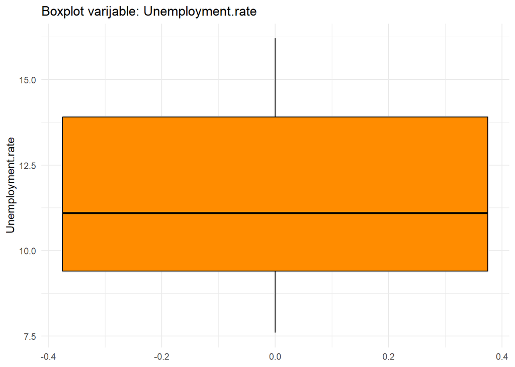

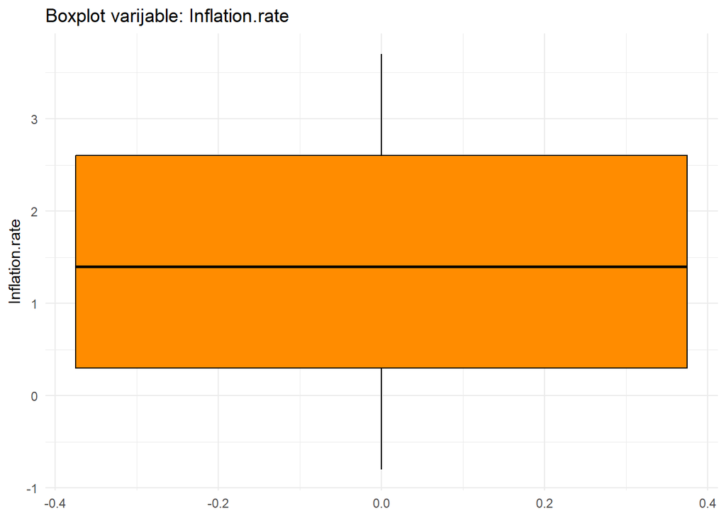

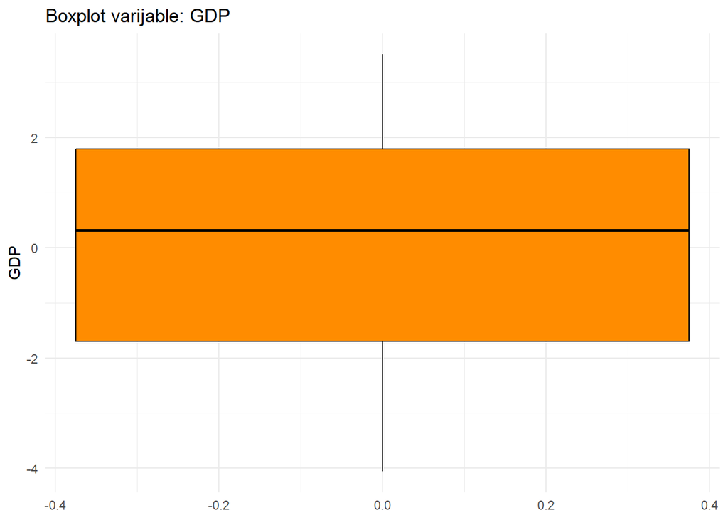

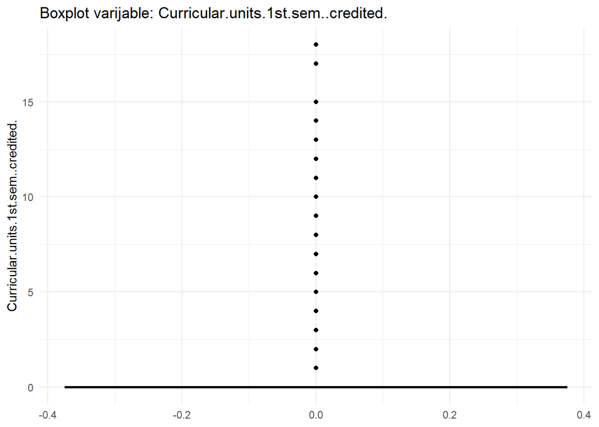

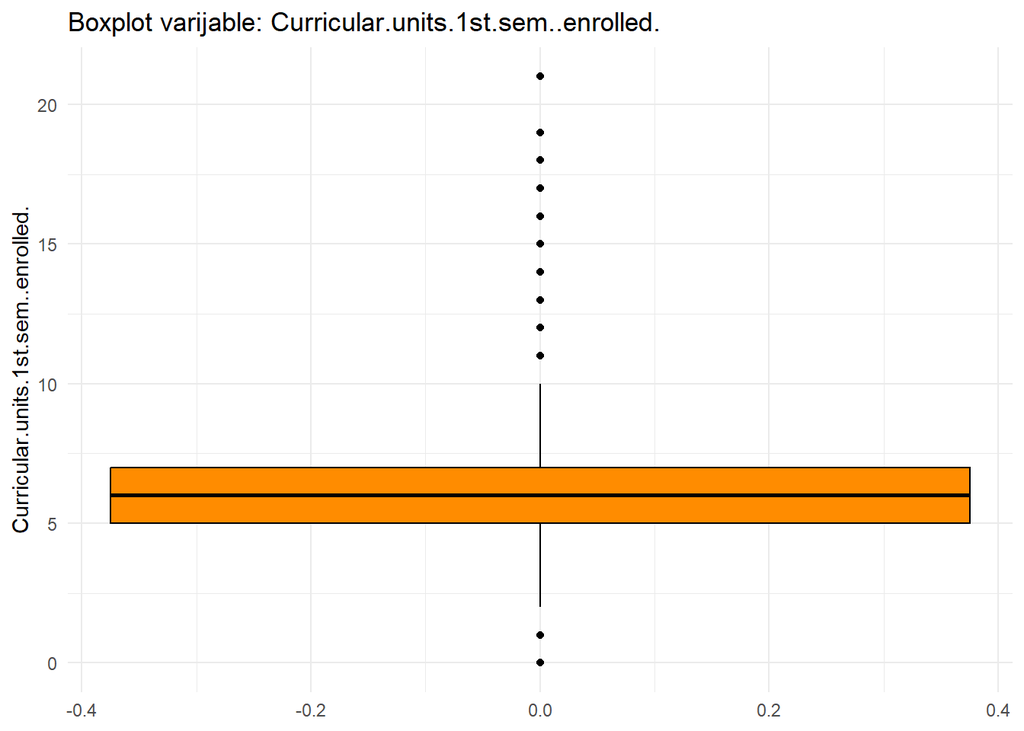

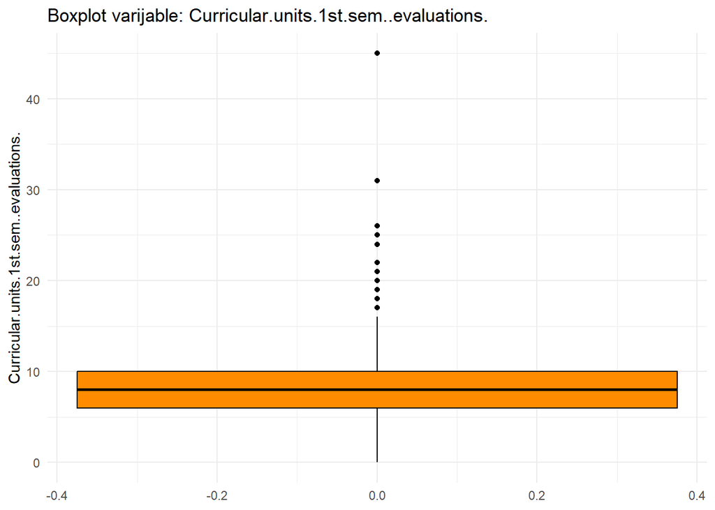

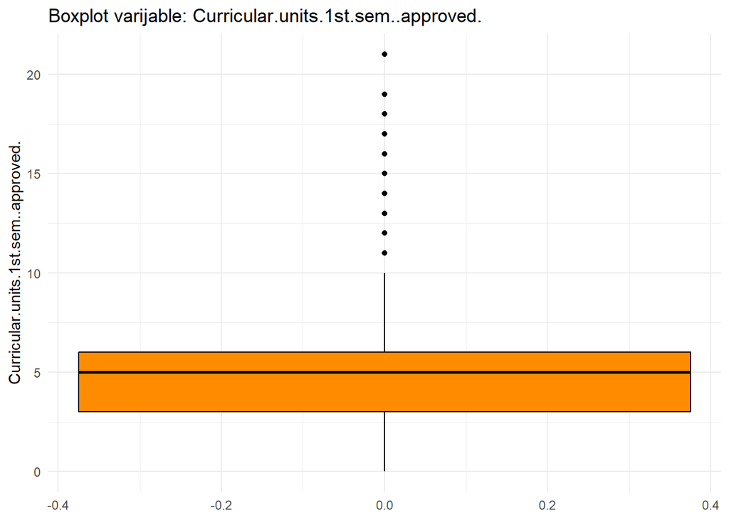

[6 more figures not shown]

```r
# Grafički prikaz boxplotova:
for (var in kvantitativne) {
  print(
    ggplot(df_sample, aes_string(y = var)) +
      geom_boxplot(fill = "darkorange", color = "black") +
      labs(title = paste("Boxplot varijable:", var), y = var) +
      theme_minimal()
  )
}
```

Na temelju 18 kvantitativnih varijabli iz podskupa, provedena je deskriptivna statistika i grafička analiza distribucije. Izračunate su mjere centralne tendencije i disperzije (srednja vrijednost, medijan, SD, kvartili), kao i ekstremne vrijednosti (min, max). Histogrami prikazuju oblik distribucije podataka, dok boxploti dodatno vizualiziraju raspon i moguća odstupanja (stršila).

## Kvalitativne varijable

```r
kvalitativne <- c(
  "Marital.status", "Application.mode", "Application.order", "Course",
  "Daytime.evening.attendance.", "Previous.qualification", "Nacionality",
  "Mother.s.qualification", "Father.s.qualification", "Mother.s.occupation",
  "Father.s.occupation", "Displaced", "Educational.special.needs", "Debtor",
  "Tuition.fees.up.to.date", "Gender", "Scholarship.holder", "International",
  "Target"
)
# Pretvorba za lakšu analizu:
# Pretvori kvalitativne varijable u factor
df_sample[, kvalitativne] <- lapply(df_sample[, kvalitativne], as.factor)
# Provjera: sve bi trebale sada imati ispravan tip
str(df_sample)
```

```
## tibble [1,500 × 37] (S3: tbl_df/tbl/data.frame)
##  $ Marital.status                                : Factor w/ 6 levels "1","2","3","4",..: 1 1 2 1 1 1 1 4 1 1 ...
##  $ Application.mode                              : Factor w/ 16 levels "1","5","7","10",..: 1 14 11 1 11 1 14 11 13 8 ...
##  $ Application.order                             : Factor w/ 6 levels "1","2","3","4",..: 1 1 1 1 1 1 1 2 1 3 ...
##  $ Course                                        : Factor w/ 17 levels "33","171","8014",..: 2 4 15 9 8 16 5 13 6 14 ...
##  $ Daytime.evening.attendance.                   : Factor w/ 2 levels "0","1": 2 2 2 2 2 2 2 2 2 2 ...
##  $ Previous.qualification                        : Factor w/ 15 levels "1","2","3","4",..: 1 12 10 1 6 1 12 1 1 1 ...
##  $ Previous.qualification..grade.                : num [1:1500] 132 120 100 140 133 ...
##  $ Nacionality                                   : Factor w/ 16 levels "1","2","6","11",..: 1 1 1 1 1 1 1 1 1 1 ...
##  $ Mother.s.qualification                        : Factor w/ 21 levels "1","2","3","4",..: 1 1 17 12 15 18 1 18 3 18 ...
##  $ Father.s.qualification                        : Factor w/ 25 levels "1","2","3","4",..: 1 11 20 21 19 21 1 20 11 21 ...
##  $ Mother.s.occupation                           : Factor w/ 26 levels "0","1","2","3",..: 5 5 1 10 1 10 5 8 5 10 ...
##  $ Father.s.occupation                           : Factor w/ 34 levels "0","1","2","3",..: 2 8 1 10 12 10 5 8 7 10 ...
##  $ Admission.grade                               : num [1:1500] 119 120 164 129 108 ...
##  $ Displaced                                     : Factor w/ 2 levels "0","1": 2 1 1 2 1 1 1 2 1 2 ...
```

[output cut: 23 more lines]

```r
# Desktiptivna statistika kval. varijabli:
# Za svaku varijablu ispis moda i frekvencijske distribucije
for (var in kvalitativne) {
  cat("🔹 Varijabla:", var, "\n")
  mod_value <- names(sort(table(df_sample[[var]]), decreasing = TRUE))[1]
  cat("   Mod:", mod_value, "\n")
  print(sort(table(df_sample[[var]]), decreasing = TRUE))
  cat("\n")
}
```

```
## 🔹 Varijabla: Marital.status
##    Mod: 1
##
##    1    2    4    5    3    6
## 1342  118   34    4    1    1
##
## 🔹 Varijabla: Application.mode
##    Mod: 1
##
##   1  17  39  43  44   7  18  51  42  53  15  16   5  10  26  27
## 587 290 254 103  69  47  46  28  21  17  13  12   9   2   1   1
##
## 🔹 Varijabla: Application.order
##    Mod: 1
##
##    1    2    3    4    5    6
## 1032  185   91   75   60   57
##
## 🔹 Varijabla: Course
##    Mod: 9500
##
## 9500 9147 9238 9773 9085 9670 9991 9254  171 8014 9070 9853 9003 9119 9130 9556
##  265  138  118  118  108  100   88   81   78   76   74   64   63   47   45   31
##   33
##    6
##
## 🔹 Varijabla: Daytime.evening.attendance.
##    Mod: 1
##
##    1    0
## 1336  164
##
## 🔹 Varijabla: Previous.qualification
##    Mod: 1
##
##    1   39   19    3   42   12   40    2    4    6   43    9   10   14   38
## 1259   72   52   40   18   16   15   10    4    4    4    2    2    1    1
##
## 🔹 Varijabla: Nacionality
##    Mod: 1
```

[output cut: 68 more lines]

```
##
##    0    1
## 1127  373
##
## 🔹 Varijabla: International
##    Mod: 0
##
##    0    1
## 1461   39
##
## 🔹 Varijabla: Target
##    Mod: Graduate
##
## Graduate  Dropout Enrolled
##      749      482      269
```